# Plotting

## Plotting basics

For the R and Python sections here, either pick one of the languages, or do both.

For R, do both `base` and `ggplot2` operations!

Note that I’m not having you do multi-panel plots in `base` R.  
Spoiler alert: it is kinda annoying.

### R

#### Greek symbols

Take the following plot:

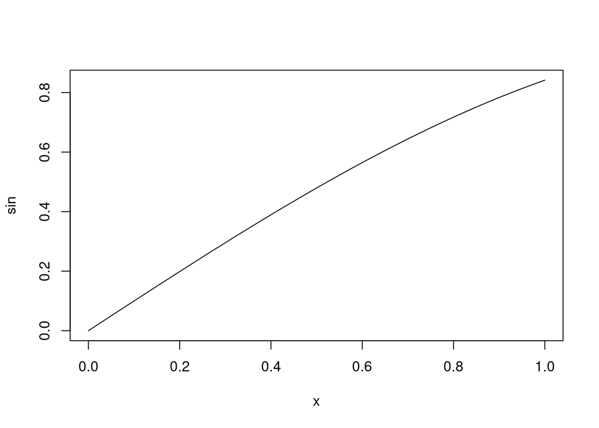

```r
plot(sin)
```

Change it so that the `x` axis label is $\sigma$ and the `y` axis label is $\tau$. Those are the Greek letters “sigma” and “tau”, respectively.

Hint: look up the R function `expression`.

Take the same plot, and change the `x` axis label to $\sigma^2_s$.

#### Color and line style (base graphics)

For the same plot as above, change the plot so that the line is red, “dot-dash”, and 3 times the default line thickness.

#### Axis labels from data

Take the graph we started with, and assume there’s a variable `y = 7`. Add a title to the graph that says $\Gamma = 7$. (That’s the Greek letter “gamma”.) Do it using the variable! Don’t “hard-code” in the value!

Hint: the function you need here is `bquote` and the horrific `.(foo)` syntax, where `foo` is a variable. Extra hint: this is one of the more obnoxious corners of R.

#### Annotations from data

Take the graph we started with, and assume there’s a variable `y = 7`. Add a text element at coordinates `x=0.1, y=0.4` to the graph that says $\Gamma = 7$.

#### Saving files

Save one of your graphics in the following formats:

- pdf with 18 point font, 10" by 10" square
- tiff with 18 point font, 10" by 10" square and the x axis font is 1/2 the global font size.
- 72 dpi png with 18 point font, 10" by 10" square
- 300 dpi png with 18 point font, 10" by 10" square

Note: please do not commit the files! Some of them will be massive! The point is for you to learn the commands.

Hints for R users:

- See `help(par)`
- Each of the above outputs will require at least 4 line of R code.

### R/ggplot

Take the following ggplot:

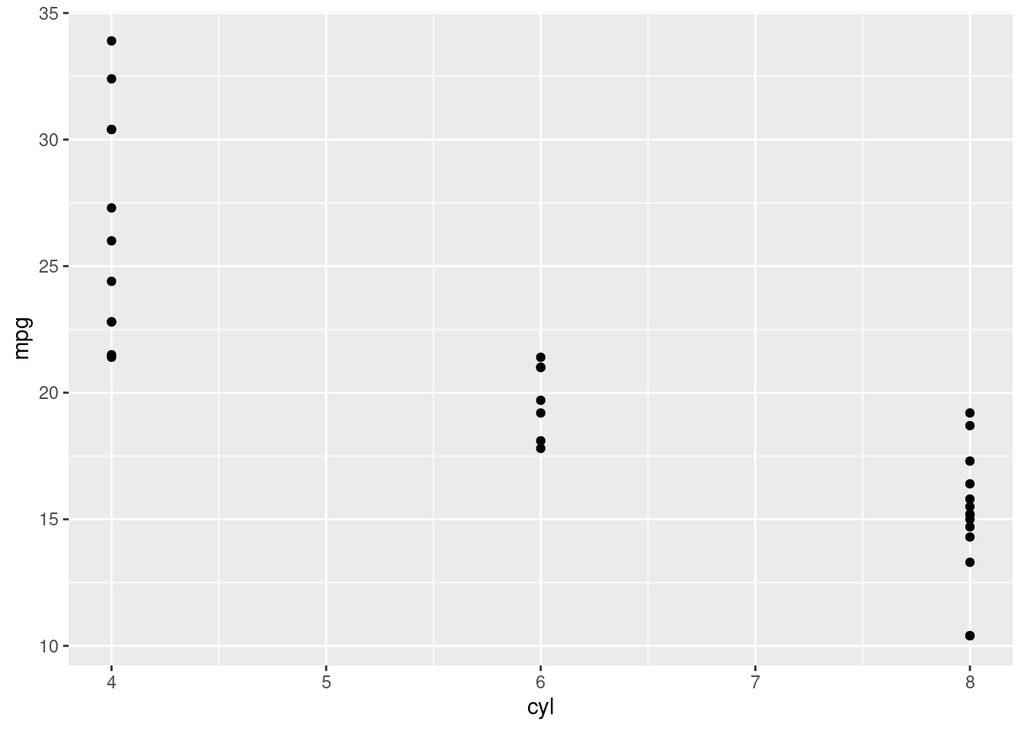

```r
library(ggplot2)
data(mtcars)
p = ggplot(mtcars, aes(x=cyl, y = mpg)) + geom_point()
p
```

Repeat the various manipulations above. Where the above instructions refer to lines, change point color/size/shape instead. New users: `ggplot` does not use `par`, `cex`, etc.. It has its own “special” ways.

Also, use the `ggpubr` library to plot two ggplots side by side. (It is fine to plot the same plot next to itself.)

Do it again, but as a 2x2 matrix of 4 plots.

### Python

Do the same manipulations described above for the R plots, but using this graph:

Hint: all of the Greek letter stuff can be accomplished with string literals and $\LaTeX$ syntax. (This is an area where Python is far easier than R.)

For the `ggplot` parts, use `seaborn`.

For multi-panel plotting, you may use `matplotlib.pyplot` or `seaborn` as you see fit. Hint: you’ll want to take a look at `GridSpec`, which is part of `matplotlib`.

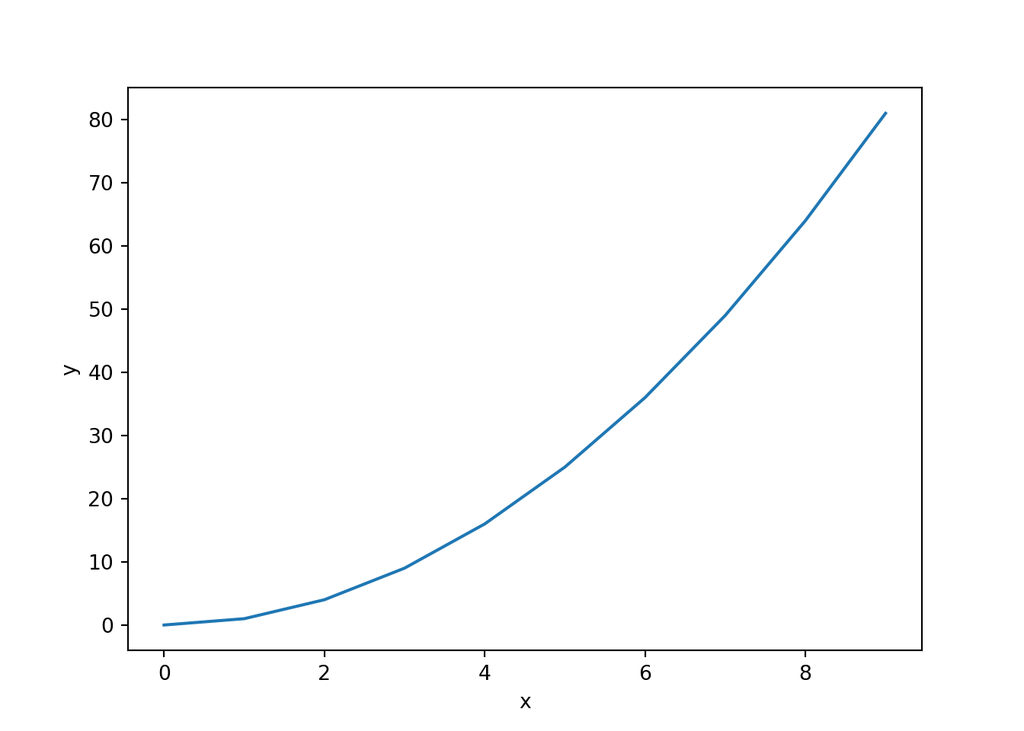

```python
import matplotlib.pyplot as plt

f, ax = plt.subplots()
x = [i for i in range(10)]
y = [i**2 for i in x]
ax.plot(x, y)
ax.set_xlabel('x')
ax.set_ylabel('y')
```

## Questions from the group

#### Narges

Heat maps with marginals in Python.

Sometimes, a “heat map” is confused with a joint distribution.

Here’s a joint distribution:

```python
import seaborn as sns
import matplotlib
print(sns.__version__)
```

```
## 0.11.1
```

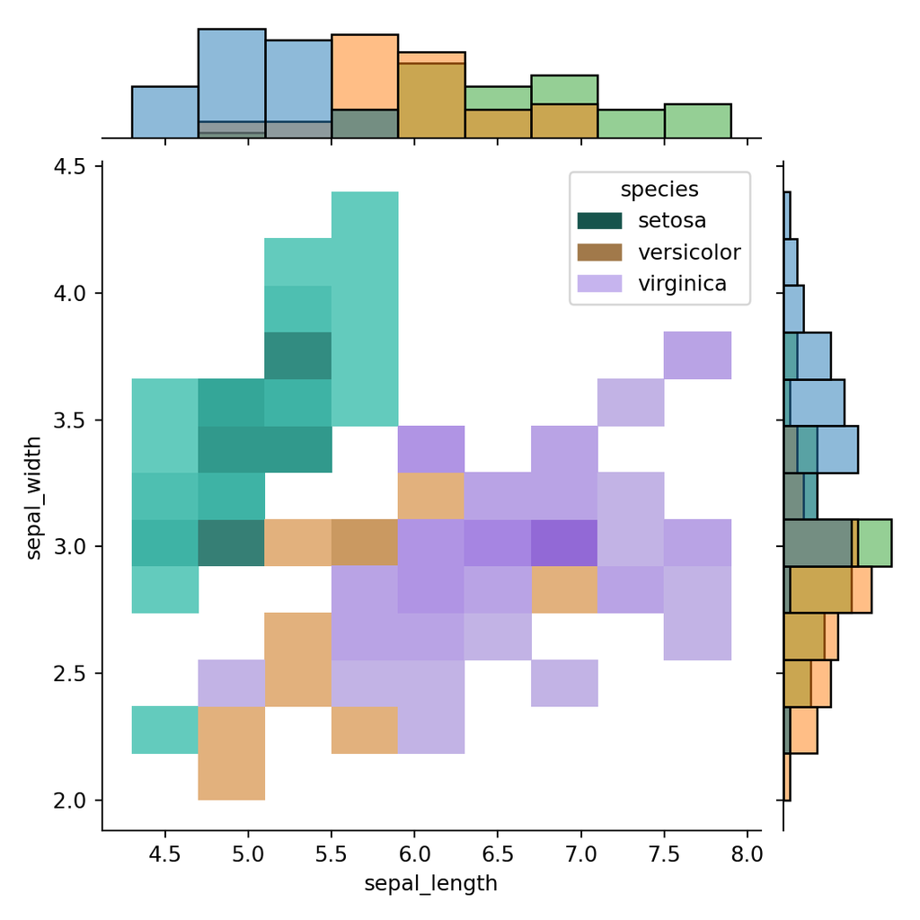

```python
df = sns.load_dataset('iris')
sns.jointplot(x=df["sepal_length"], y=df["sepal_width"], kind='hist', palette='cubehelix', hue=df['species']);
plt.show()
```

And a heat map:

```python
import numpy as np
import pandas as pd
np.random.seed(42)

data = np.random.multivariate_normal([0., -0.25], [[1., 0.0], [0.0, 4.]], 10000)
print(data)
```

```
## [[-0.1382643   0.74342831]
##  [ 1.52302986  1.04537708]
##  [-0.23413696 -0.71830675]
##  ...
##  [ 0.38782734  1.65518102]
##  [ 0.37835397  2.50473316]
##  [-1.6199198   3.17705946]]
```

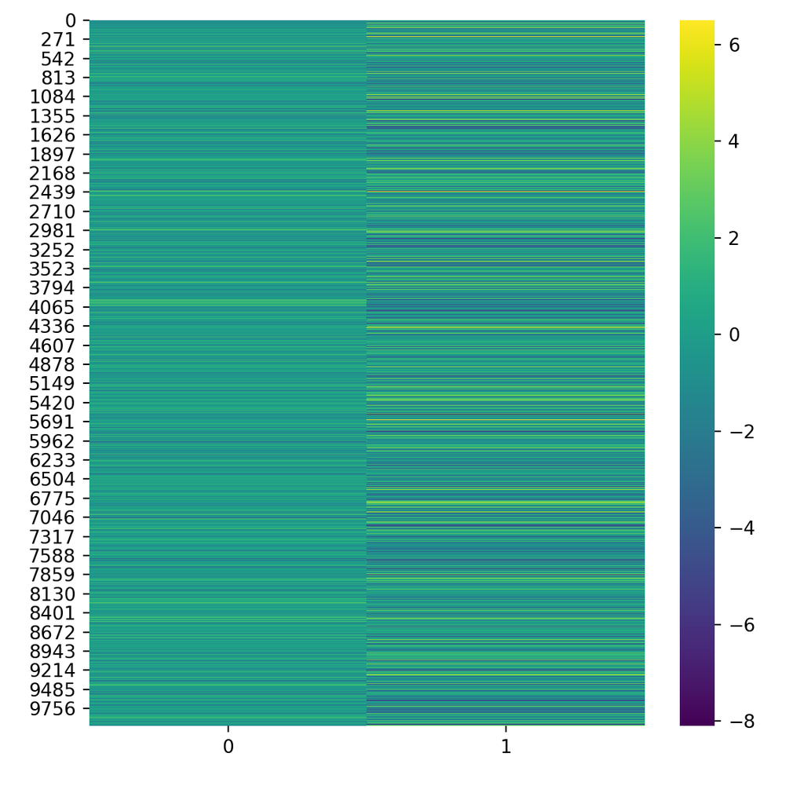

```python
sns.heatmap(data, cmap="viridis")
```

The joint density version of the above is:

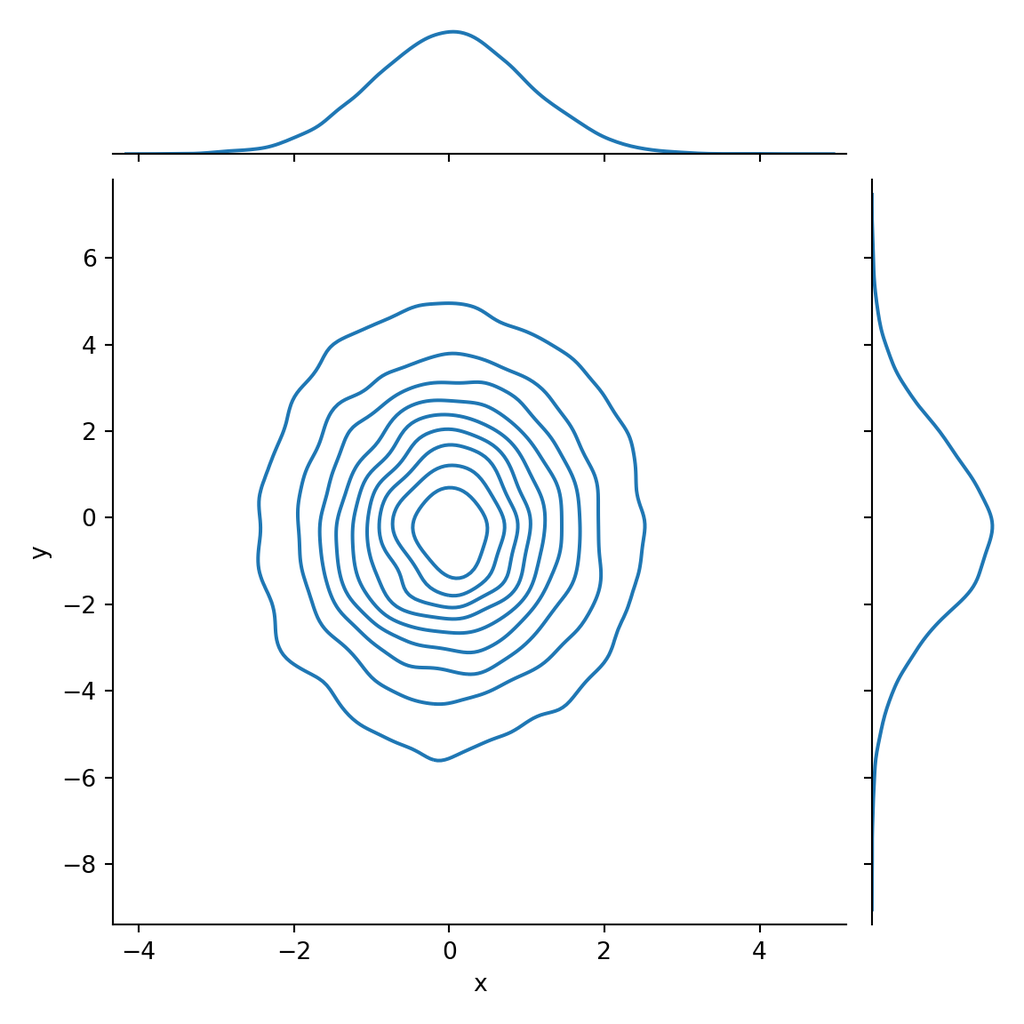

```python
x, y = data.T
df = pd.DataFrame({'x': x,'y': y})
sns.jointplot(x=df['x'], y=df['y'], kind='kde');
plt.show()
```

Or,

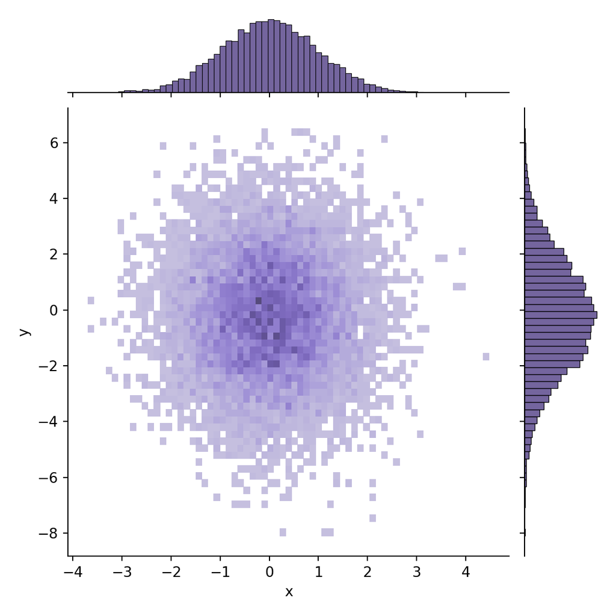

```python
sns.set_palette('viridis')
sns.jointplot(x=df['x'], y=df['y'], kind='hist');
plt.show()
```

Or, super-sneaky:

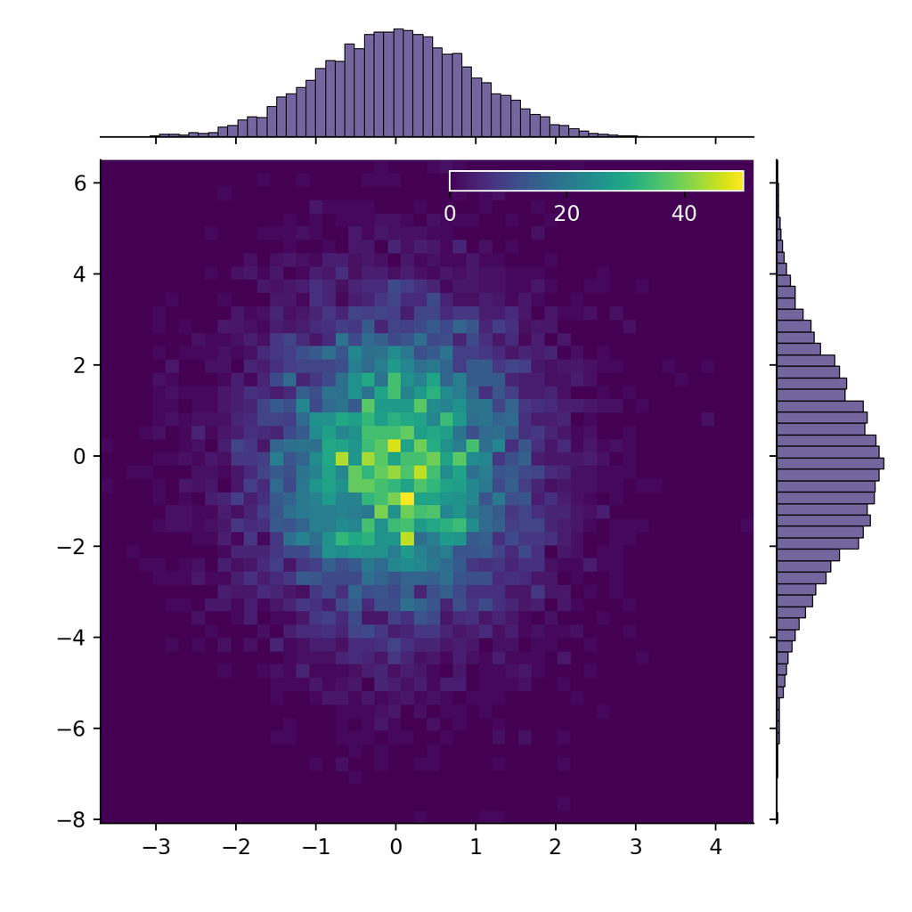

```python
from mpl_toolkits.axes_grid1.inset_locator import inset_axes

ax = sns.jointplot(x=df['x'], y=df['y'], kind='hist');
# replace main plot with plt.hist2d
ax.ax_joint.cla()
plt.sca(ax.ax_joint)
h = plt.hist2d(df.x, df.y, bins=(50, 50), cmap='viridis')

# Add color bar onto inset axis
cbaxes = inset_axes(ax.ax_joint, width="45%", height="3%", loc=1)
cbaxes.axis['bottom'].major_ticklabels.set_color('white')
cbar = plt.colorbar(h[3], cax=cbaxes, orientation='horizontal')
cbar.outline.set_edgecolor('white')
plt.show()
```

#### Parvan - Plotting from summary stats

This is hard, and not in the usual domain of statistical software.

An incomplete R solution follows. I couldn’t be bothered to get the x-axis spacing to work out, as I can already tell it won’t generalize to a plot with more columns.

Get the raw data and just plot them, I guess.

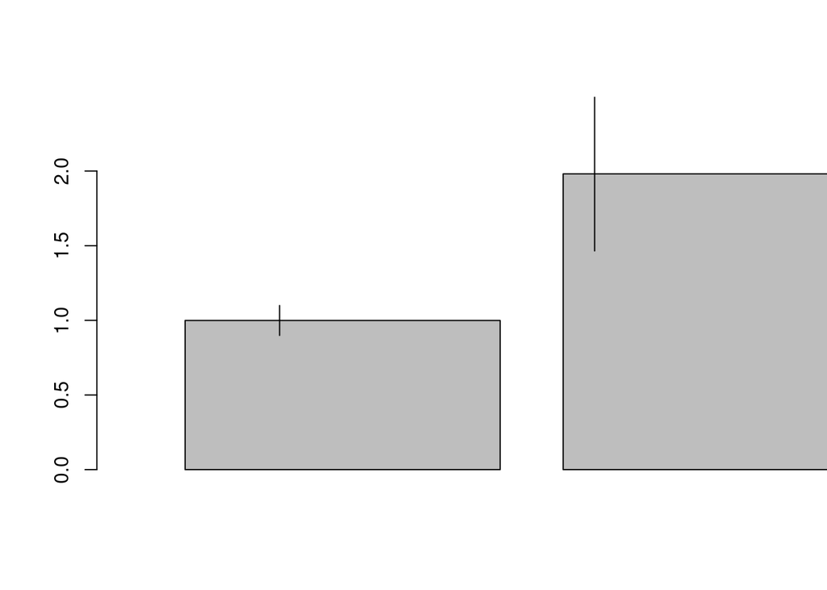

```r
a = rnorm(1e3, 1, 0.1)
b = rnorm(1e3, 2, 0.5)
heights = c(mean(a), mean(b))
std_dev = c(sd(a), sd(b))
xlim=c(0, length(heights))
barplot(heights, xlim=xlim, ylim=c(0, max(heights) + max(std_dev)))

# Manually add +/- 1 sd
segments(0.5, heights[1], 0.5, heights[1] + std_dev[1])
segments(0.5, heights[1], 0.5, heights[1] - std_dev[1])
segments(1.5, heights[2], 1.5, heights[2] + std_dev[2])
segments(1.5, heights[2], 1.5, heights[2] - std_dev[2])
```

#### Johnny - plots aren’t as nice as Graph Pad Prism:

Honestly, I didn’t see anything in that package that couldn’t be done in R. In fact, I almost suspect that they use R or Python as a back end. I think it is just a question of adjusting styles.

### Super special hints for Python users

#### Use $\LaTeX$ for font rendering.

Some folks don’t like the default `matplotlib` fonts. Use the beautiful `Computer Modern` font instead.

Warning: requires a full $\LaTeX$ setup! I had to do the following first on my Ubuntu:

```bash
sudo apt install cm-super dvipng
```

The code:

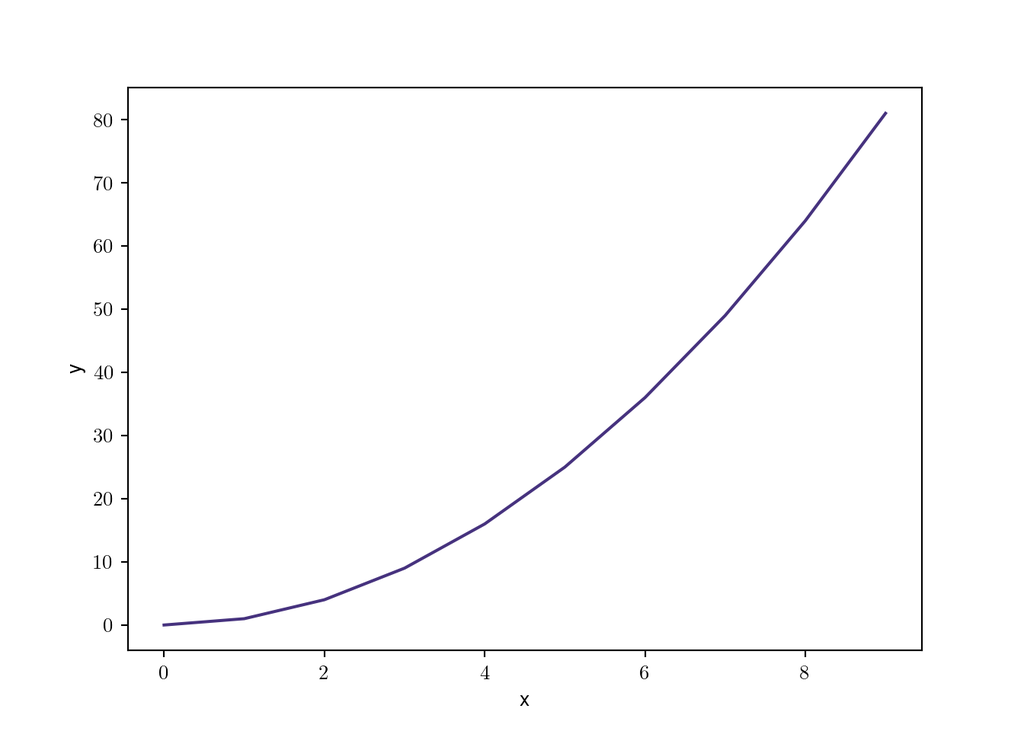

```python
import matplotlib.pyplot as plt
from matplotlib import rc
rc('font',**{'family':'sans-serif','sans-serif':['Helvetica']})
## for Palatino and other serif fonts use:
#rc('font',**{'family':'serif','serif':['Palatino']})
rc('text', usetex=True)

f, ax = plt.subplots()
x = [i for i in range(10)]
y = [i**2 for i in x]
ax.plot(x, y)
ax.set_xlabel('x')
ax.set_ylabel('y')
```

#### Remote plotting

On Unix systems, the default display back-end for `matplotlib` requires `X11`. This requirement poses a problem when trying to have an HPC job generate a plot–a user authenticated to use an `X` display does not exist. Likewise, it is a problem when working remotely via `ssh` and you didn’t use `-Y` to connect, etc..

Solution: switch the back-end to `agg`:

```python
# Not executed in this notebook!
import matplotlib
matplotlib.use('agg')
```